# Coffee Survey Proposal

Proposal

Project description: How much money do different age groups spend on coffee? How do coffee type preferences differ by age group?

Author

Affiliation

Stats for Stacks

School of Information, University of Arizona

```r
if (!require("pacman"))
  install.packages("pacman")
# use this line for installing/loading
pacman::p_load(readr,dplyr,ggplot2,scico,here,tidyverse,ggrepel,devtools,
               ggridges,dsbox,fs,janitor)
```

## Dataset

```r
coffee_survey <- read_csv('https://raw.githubusercontent.com/rfordatascience/tidytuesday/master/data/2024/2024-05-14/coffee_survey.csv')

glimpse(coffee_survey)
```

```
Rows: 4,042
Columns: 57
$ submission_id                <chr> "gMR29l", "BkPN0e", "W5G8jj", "4xWgGr", "…
$ age                          <chr> "18-24 years old", "25-34 years old", "25…
$ cups                         <chr> NA, NA, NA, NA, NA, NA, NA, NA, "Less tha…
$ where_drink                  <chr> NA, NA, NA, NA, NA, NA, "At a cafe, At th…
$ brew                         <chr> NA, "Pod/capsule machine (e.g. Keurig/Nes…
$ brew_other                   <chr> NA, NA, NA, NA, NA, NA, NA, NA, NA, NA, N…
$ purchase                     <chr> NA, NA, NA, NA, NA, NA, "National chain (…
$ purchase_other               <chr> NA, NA, NA, NA, NA, NA, NA, NA, NA, NA, N…
$ favorite                     <chr> "Regular drip coffee", "Iced coffee", "Re…
$ favorite_specify             <chr> NA, NA, NA, NA, NA, NA, NA, NA, NA, NA, N…
$ additions                    <chr> "No - just black", "Sugar or sweetener, N…
$ additions_other              <chr> NA, NA, NA, NA, NA, NA, NA, NA, NA, NA, N…
$ dairy                        <chr> NA, NA, NA, NA, NA, NA, NA, NA, NA, NA, N…
```

[output cut: 44 more lines]

```r
coffee_survey |>
  colnames() |>
  cat(sep = "\n")
```

```
submission_id
age
cups
where_drink
brew
brew_other
purchase
purchase_other
favorite
favorite_specify
additions
additions_other
dairy
sweetener
style
strength
roast_level
caffeine
expertise
coffee_a_bitterness
coffee_a_acidity
coffee_a_personal_preference
coffee_a_notes
coffee_b_bitterness
coffee_b_acidity
coffee_b_personal_preference
coffee_b_notes
coffee_c_bitterness
coffee_c_acidity
coffee_c_personal_preference
coffee_c_notes
coffee_d_bitterness
coffee_d_acidity
coffee_d_personal_preference
coffee_d_notes
prefer_abc
prefer_ad
prefer_overall
wfh
total_spend
why_drink
why_drink_other
taste
know_source
most_paid
most_willing
value_cafe
spent_equipment
value_equipment
gender
gender_specify
education_level
ethnicity_race
ethnicity_race_specify
employment_status
number_children
political_affiliation
```

```r
coffee_survey <- coffee_survey|>
  janitor::clean_names()

unique(coffee_survey$age)
```

```
[1] "18-24 years old" "25-34 years old" "35-44 years old" "55-64 years old"
[5] NA                "<18 years old"   ">65 years old"   "45-54 years old"
```

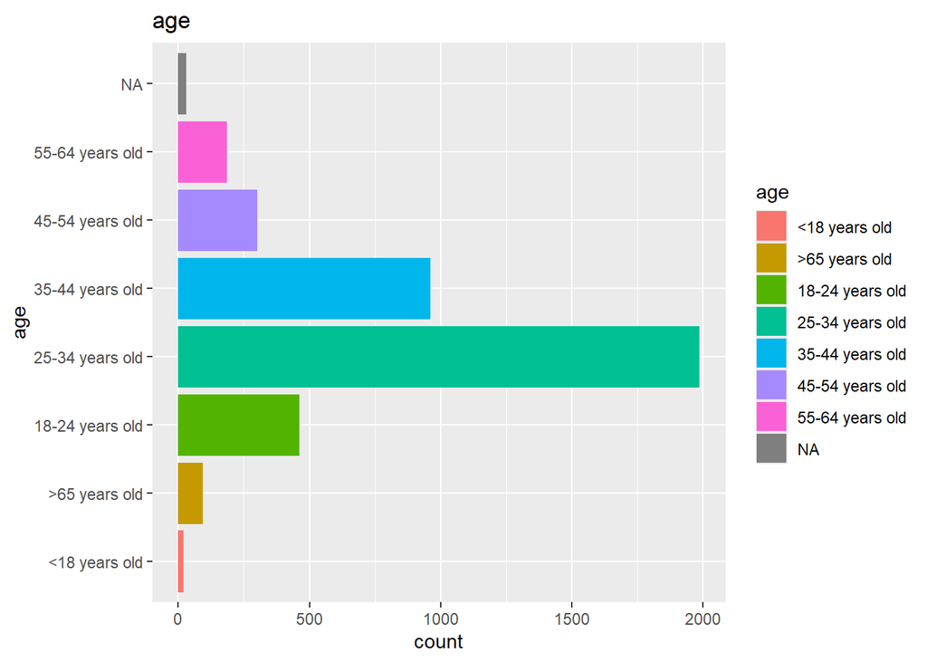

```r
ggplot(coffee_survey)+geom_bar(aes(age,fill=age))+
  coord_flip(clip = "off")+labs(title='age')
```

```r
unique(coffee_survey$favorite)
```

```
 [1] "Regular drip coffee"              "Iced coffee"
 [3] "Latte"                            "Pourover"
 [5] NA                                 "Other"
 [7] "Cortado"                          "Cappuccino"
 [9] "Espresso"                         "Cold brew"
[11] "Americano"                        "Mocha"
[13] "Blended drink (e.g. Frappuccino)"
```

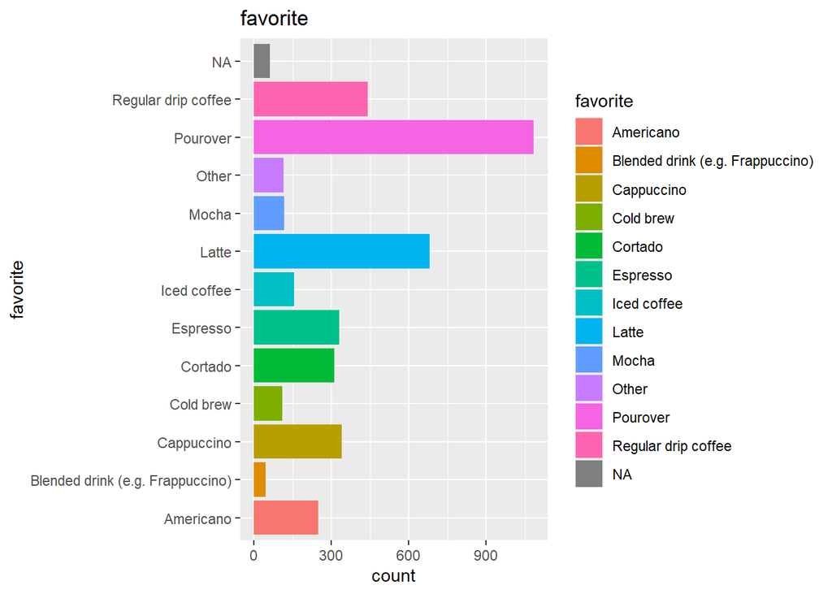

```r
ggplot(coffee_survey)+geom_bar(aes(favorite,fill=favorite))+
  coord_flip(clip = "off")+labs(title='favorite')
```

```r
unique(coffee_survey$gender)
```

```
[1] NA                       "Other (please specify)" "Female"
[4] "Male"                   "Non-binary"             "Prefer not to say"
```

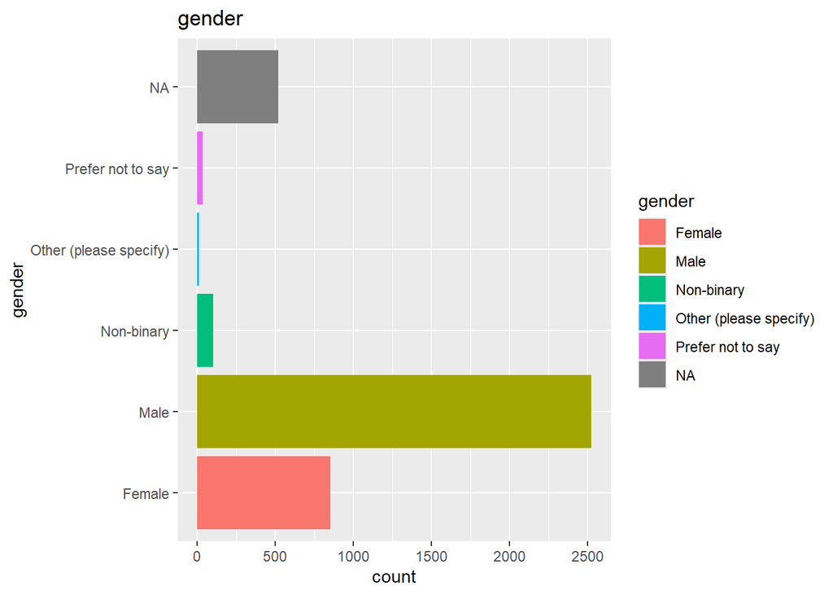

```r
ggplot(coffee_survey)+geom_bar(aes(gender,fill=gender))+
  coord_flip(clip = "off")+labs(title='gender')
```

```r
unique(coffee_survey$ethnicity_race)
```

```
[1] NA                              "Other (please specify)"
[3] "White/Caucasian"               "Asian/Pacific Islander"
[5] "Black/African American"        "Hispanic/Latino"
[7] "Native American/Alaska Native"
```

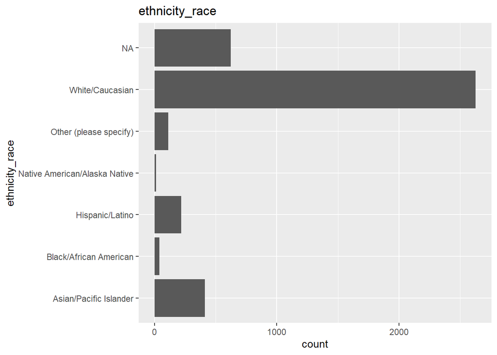

```r
ggplot(coffee_survey)+geom_bar(aes(ethnicity_race))+
  coord_flip(clip = "off")+labs(title='ethnicity_race')
```

```r
unique(coffee_survey$education_level)
```

```
[1] NA                                   "Bachelor's degree"
[3] "Master's degree"                    "Less than high school"
[5] "Some college or associate's degree" "Doctorate or professional degree"
[7] "High school graduate"
```

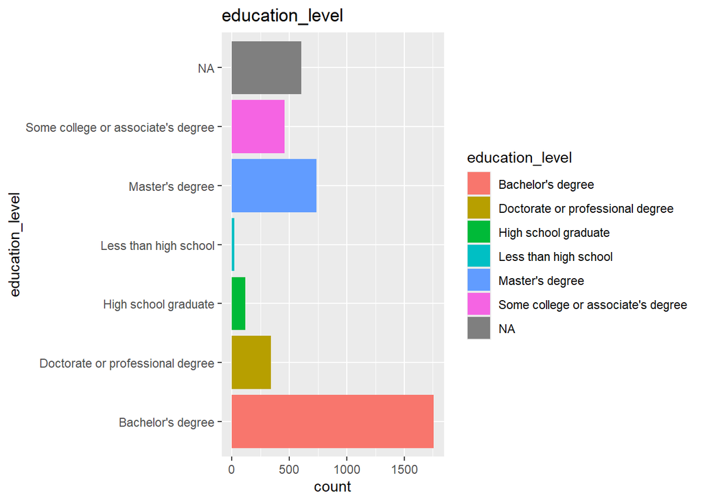

```r
ggplot(coffee_survey)+geom_bar(aes(education_level,fill=education_level))+
  coord_flip(clip = "off")+labs(title='education_level')
```

```r
unique(coffee_survey$employment_status)
```

```
[1] NA                   "Employed full-time" "Unemployed"
[4] "Student"            "Employed part-time" "Retired"
[7] "Homemaker"
```

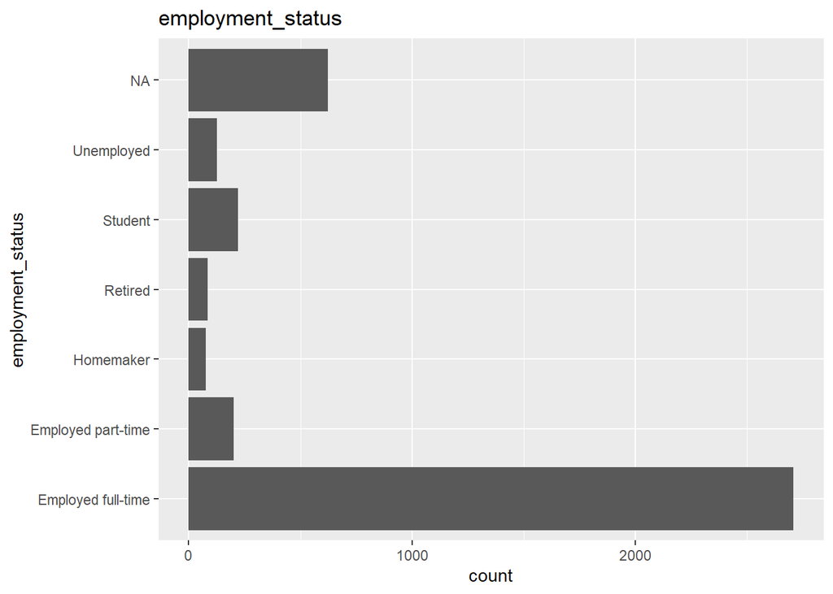

```r
ggplot(coffee_survey)+geom_bar(aes(employment_status))+
  coord_flip(clip = "off")+labs(title='employment_status')
```

```r
unique(coffee_survey$total_spend)
```

```
[1] NA         ">$100"    "$40-$60"  "$20-$40"  "$60-$80"  "<$20"     "$80-$100"
```

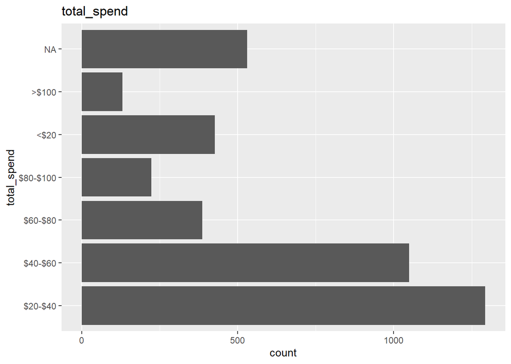

```r
ggplot(coffee_survey)+geom_bar(aes(total_spend))+
  coord_flip(clip = "off")+labs(title='total_spend')
```

```r
unique(coffee_survey$political_affiliation)
```

```
[1] NA               "Democrat"       "No affiliation" "Independent"
[5] "Republican"
```

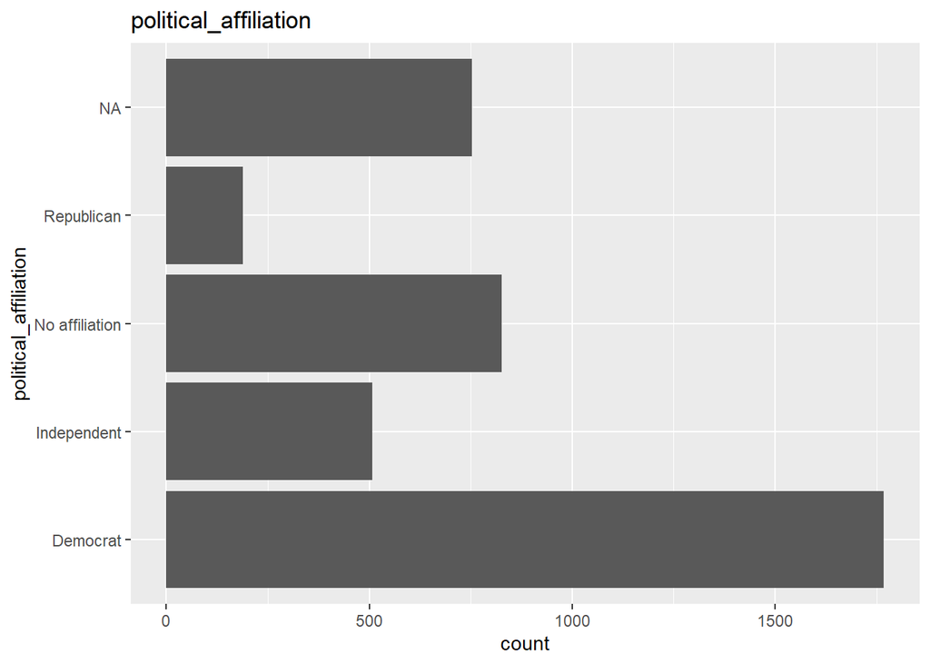

```r
ggplot(coffee_survey)+geom_bar(aes(political_affiliation))+
  coord_flip(clip = "off")+labs(title='political_affiliation')
```

## Dataset Description

- The coffee survey was collected from people participated in a YouTube event called the “Great American Coffee Taste Test”. This event was primairly to taste test 4 different types of coffee, while the entire survey collected a wide variety of information. It has a total of 4042 participants/observations (rows), and 57 variables (columns).
- I chose this data set because I am an avid coffee drinker and would like to know what other fellow coffee lovers like to drink, and if they spend as much money on coffee as I do. I also used to work at a local Mexican style coffee shop named Tierra Mia in the Los Angles area. Exploring this data set would just give me insight into the community that I would like to have.

## Questions

Q1: Which age group spends the most money on coffee per month? There are 7 age groups. 5 range from 18-65. One is <18, and another is >65. Effectively covering ages from all walks of life.

Q2: What is the favorite kinds of coffee for each group: gender, education level, employment status, and political affiliations, and ethnicity/race?

## Analysis plan

- I am planning on creating either a heat map like plot of the with count as the gradient or stacked bar charts
- The variables I need to use are listed below along with the question that was asked to participants in the survey:
  - total_spend: In total, how much money do you typically spend on coffee in a month?
  - favorite: What is your favorite coffee drink?
  - age: What is your age?
  - employment_status
  - education_level
  - gender
  - political_affiliation
  - ethnicity_race
  - Will have to create a count of total_spend variable per age group and count of favorite drinks per age group.

Task List:

| Task Name | Status | Assignee | Due | Priority | Summary |
| --- | --- | --- | --- | --- | --- |
| Import Data | complete | luis | 05/29 | Low | use read_csv to import data from the tidyTuesday github repo |
| Explore Data | complete | luis | 06/01 | Moderate | plot counts for each of the categorical variables to get a feel for whats in the data |
| Q1 | Complete | luis | 06/03 | High | how much money does each age group spend on coffee? |
| Q2 | Complete | luis | 06/05 | High | Favorite coffee? |
| Write Up | Complete | luis | 06/07 | High |  |
| Presentation | Complete | luis | 06/10 | High |  |
| Final Review | Complete | luis | 06/15 | Moderate |  |